# Case1 - Cell Segmentation

2024-04-30

## Chapter 11 - Image Data - Case 1 Cell (nuclei and bodies) Segmentation

```r
#BiocManager::install("genefilter")
#Libraries
library(EBImage)
library(htmlwidgets)
library(ggplot2)
library(cba)
library(genefilter)
library(GGally)
library(tibble)
```

### 1. Background

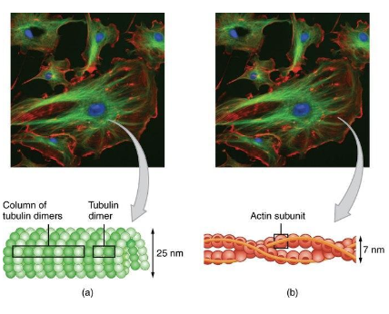

  Tubulin (green) and actin (red)

### 2. Import and visualization

```r
#Read images of 3 channels
cells = readImage(system.file("images", c("image-DAPI.tif", "image-FITC.tif", "image-Cy3.tif"), package = "MSMB"))
cells
```

```
## Image
##   colorMode    : Grayscale
##   storage.mode : double
##   dim          : 340 490 3
##   frames.total : 3
##   frames.render: 3
##
## imageData(object)[1:5,1:6,1]
##             [,1]        [,2]        [,3]        [,4]        [,5]        [,6]
## [1,] 0.001724269 0.001693751 0.001739528 0.001678492 0.001724269 0.001663233
## [2,] 0.001739528 0.001724269 0.001693751 0.001693751 0.001739528 0.001709010
## [3,] 0.001678492 0.001754788 0.001724269 0.001724269 0.001678492 0.001663233
## [4,] 0.001724269 0.001709010 0.001693751 0.001739528 0.001693751 0.001647974
## [5,] 0.001739528 0.001709010 0.001770047 0.001678492 0.001724269 0.001678492
```

```r
apply(cells, 3, range) #Check min max
```

```
##       image-DAPI  image-FITC   image-Cy3
## [1,] 0.001586938 0.002899214 0.001663233
## [2,] 0.031204700 0.062485695 0.055710689
```

The display function expects values in the range [0, 1]. Normalize cells prior to plotting

The textbook uses an approximation approach: cells[,,1] = 32 * cells[,,1] #for DAPI cells[,,2:3] = 16 * cells[,,2:3] # for FITC and Cy3

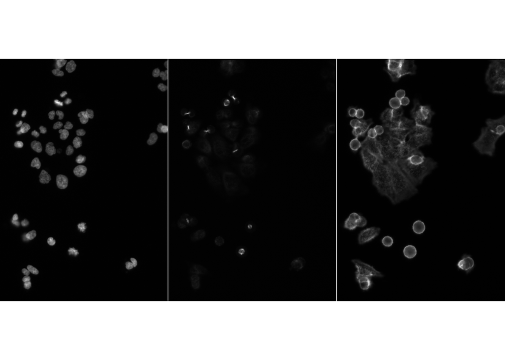

```r
cells_norm <- EBImage::normalize(cells, ft=c(0,1))
EBImage::display(cells_norm, all = TRUE, nx=numberOfFrames(cells), method = "raster")
```

Create an RGB stack

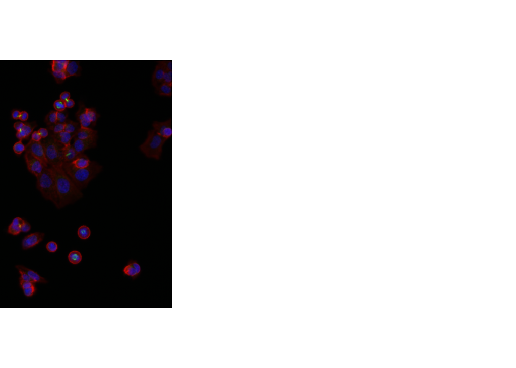

```r
cells_stack <- rgbImage(red=cells_norm[,,3], green=cells_norm[,,2], blue=cells_norm[,,1])
EBImage::display(cells_stack, all = TRUE, nx=numberOfFrames(cells), method = "raster")
```

### 2. Image processing

filter2 = 2D Convolution Filter Convolution filter - For each pixel in the image you are going to create a little square around the pixel. Lets say you take the 8 neighbors next to a pixel (including diagonals even though do not matter here), and we perform a weighted average to get the middle pixel.

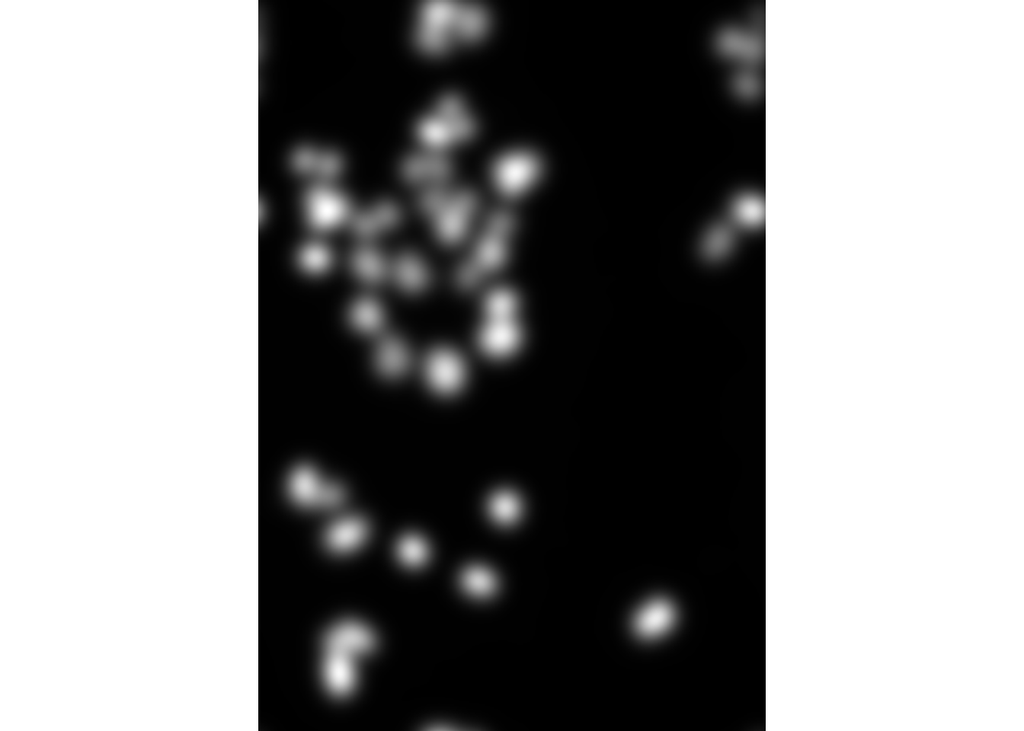

```r
w = makeBrush(size = 51, shape = "gaussian", sigma = 7)
nucSmooth <- filter2(getFrame(cells, 1), w)
nucSmooth_norm <- EBImage::normalize(nucSmooth, ft=c(0,1))
EBImage::display(nucSmooth_norm, all = TRUE, method = "raster")
```

In the Gaussian blur case it breaks down to two one dimensional operations. For each pixel take the some amount of pixels next to a pixel in the row direction only.

Let’s use a sigma of 1 pixel for the DNA channel and 3 pixels for actin and tubulin.

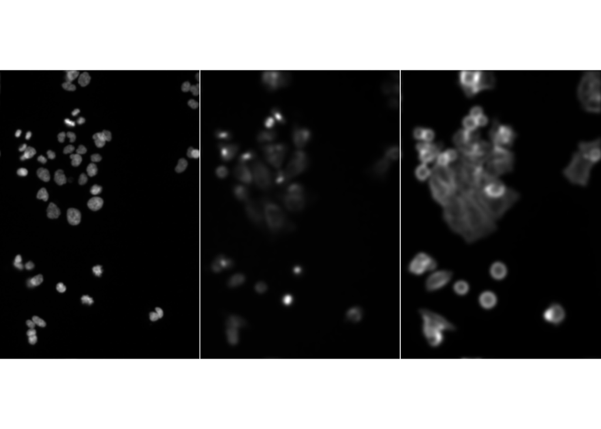

```r
cellsSmooth_gaus = Image(dim = dim(cells))
sigma = c(1, 3, 3)
for(i in seq_along(sigma))
  cellsSmooth_gaus[,,i] = filter2( cells[,,i],
         filter = makeBrush(size = 51, shape = "gaussian",
                            sigma = sigma[i]) )

cellsSmooth_gaus_norm <- EBImage::normalize(cellsSmooth_gaus, ft=c(0,1))
EBImage::display(cellsSmooth_gaus_norm, all = TRUE, nx=numberOfFrames(cells), method = "raster")
```

### 3. Image segmentation

##### 3.1 Segmentation of nuclei

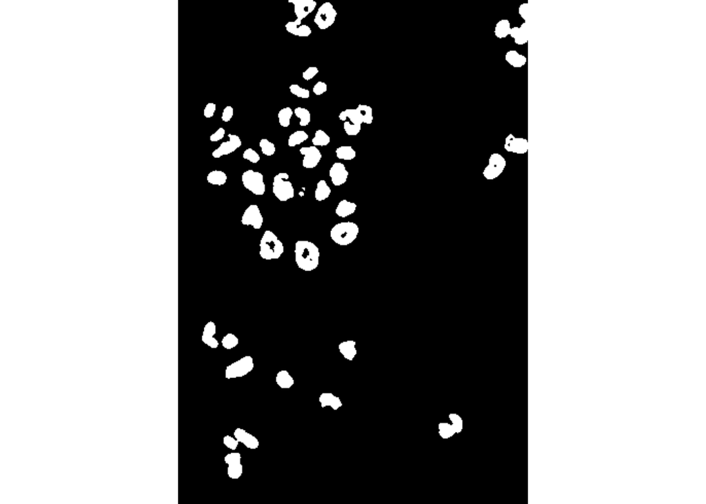

```r
disc = makeBrush(21, "disc")
disc = disc / sum(disc)
offset = 0.02

nucThresh = (cellsSmooth_gaus_norm[,,1] - filter2(cellsSmooth_gaus_norm[,,1], disc) > offset)

#Convert boolean to [0,1]
nucThresh_num <- 1*nucThresh
EBImage::display(nucThresh_num,  method = "raster")
```

Let us apply morphological opening to our image. The result of this is subtle, and you will have to zoom into the images to spot the differences, but this operation manages to smoothen out some pixel-level features in the binary images that for our application are undesirable.

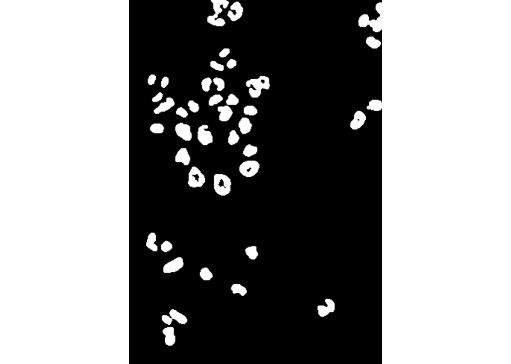

```r
nucOpened = EBImage::opening(nucThresh, kern = makeBrush(5, shape = "disc"))

#Convert boolean to [0,1]
nucOpened_num <- 1*nucOpened
EBImage::display(nucOpened_num,  method = "raster")
```

```r
nucSeed = bwlabel(nucOpened)
table(nucSeed)
```

```
## nucSeed
##      0      1      2      3      4      5      6      7      8      9     10
## 155173    525    340    603    228    121    125    159    119    544    116
##     11     12     13     14     15     16     17     18     19     20     21
##    189    184    116    186    195    306    248    170    312    195    148
##     22     23     24     25     26     27     28     29     30     31     32
##    351    291    388    204    390    210    228    325    445    421    501
##     33     34     35     36     37     38     39     40     41     42
##    258    169    226    381    216    229    347    271    128    319
```

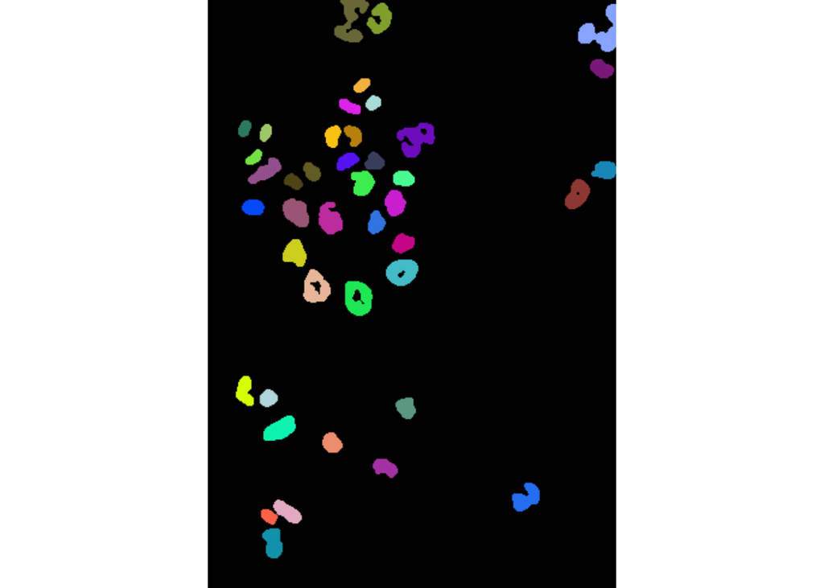

```r
EBImage::display(colorLabels(nucSeed),  method = "raster")
```

```r
nuclei = propagate(cellsSmooth_gaus[,,1], nucSeed, mask = nucOpened)
nuclei
```

```
## Image
##   colorMode    : Grayscale
##   storage.mode : integer
##   dim          : 340 490
##   frames.total : 1
##   frames.render: 1
##
## imageData(object)[1:5,1:6]
##      [,1] [,2] [,3] [,4] [,5] [,6]
## [1,]    0    0    0    0    0    0
## [2,]    0    0    0    0    0    0
## [3,]    0    0    0    0    0    0
## [4,]    0    0    0    0    0    0
## [5,]    0    0    0    0    0    0
```

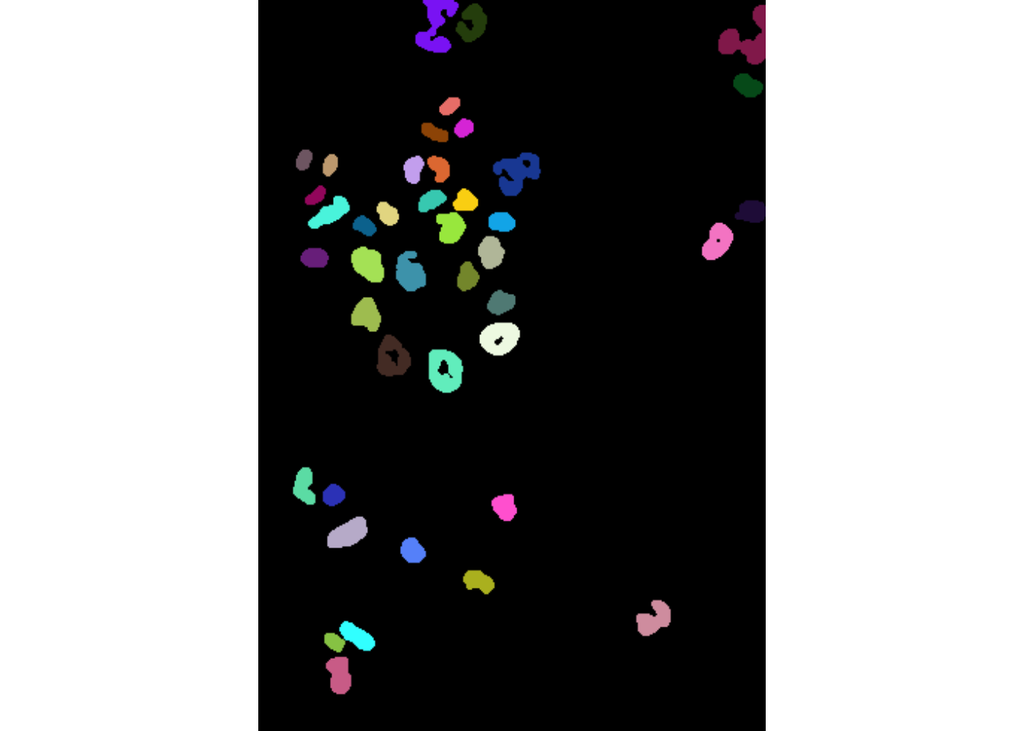

```r
EBImage::display(colorLabels(nuclei),  method = "raster")
```

##### 3.2 Segmentation of nuclei+cell bodies

Visualize the intensity in logarithm scale. Why? This is the fact that human perception of stimuli like sound and light is not linear, but instead closer to logarithmic. Equal increments on a logrithmic scale better equate to human perception. https://www.quora.com/Why-do-we-use-a-logarithmic-scale-for-intensity

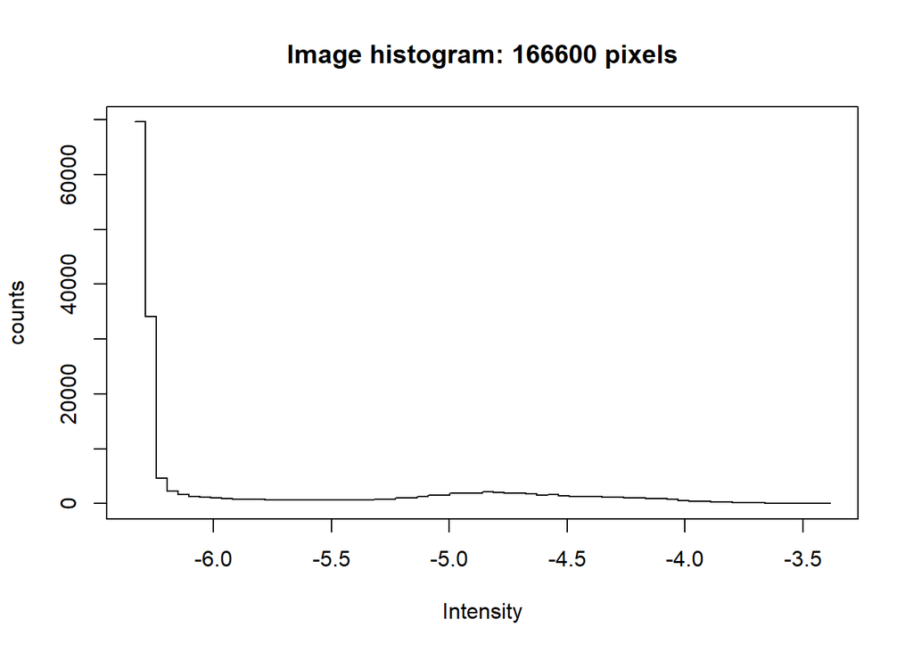

```r
hist(log(cellsSmooth_gaus[,,3]) )
```

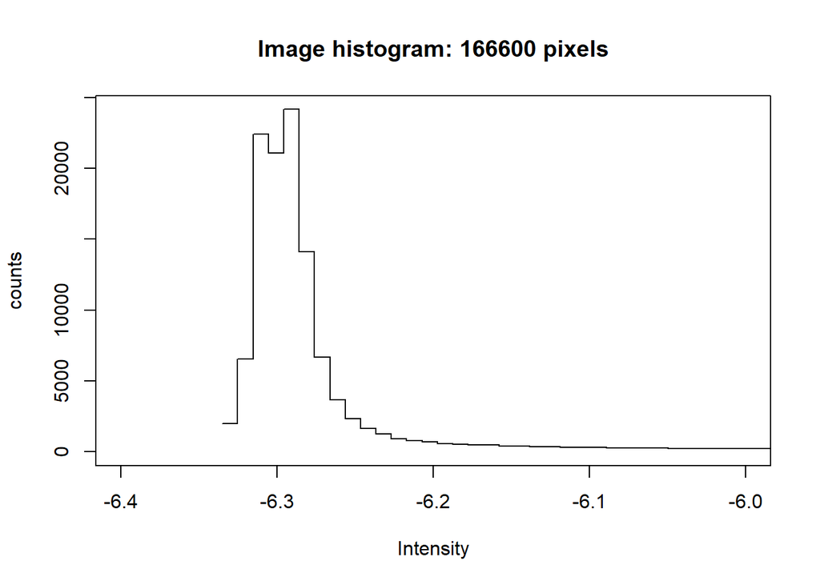

```r
hist(log(cellsSmooth_gaus[,,3]), xlim = -c(6.4, 6.0), breaks = 300) #300bins
```

Looking at the these histograms for many images, we can set up the following model for the purpose of segmentation: the signal in the cytoplasmic channels of the Image cells is a mixture of two distributions, - a log-Normal background and - a foreground with another, unspecified, rather flat, but mostly non-overlapping distribution

Moreover the majority of pixels are from the background. We can then find robust estimates for the location and width parameters of the log-Normal component from the half range mode (implemented in the package genefilter) and from the root mean square of the values that lie left of the mode.

Half range mode - finding the densest half range that is an interval whose width equals half the current range, and which contains the maximal number of observations.

Threshold = location of half-range + (6* width) The choice of the number 6 here is ad hoc; we could make the choice of threshold more objective by estimating the weights of the two mixture components and assigning each pixel to either fore- or background based on its posterior probability according to the mixture model. More advanced segmentation methods use the fact that this is really a classification problem and include additional features and more complex classifiers to separate foreground and background regions

```r
bgPars = function(x) {
  x    = log(x)
  loc  = half.range.mode( x )
  left = (x - loc)[ x < loc ]
  wid  = sqrt( mean(left^2) )
  thr = loc + 6*wid
  c(loc = loc, wid = wid, thr = thr)
}
cellBg = apply(cellsSmooth_gaus, MARGIN = 3, FUN = bgPars)
cellBg
```

```
##            [,1]        [,2]        [,3]
## loc -6.36750555 -5.71686371 -6.29450554
## wid  0.00635322  0.01121337  0.01528207
## thr -6.32938623 -5.64958349 -6.20281309
```

Visualize threshold

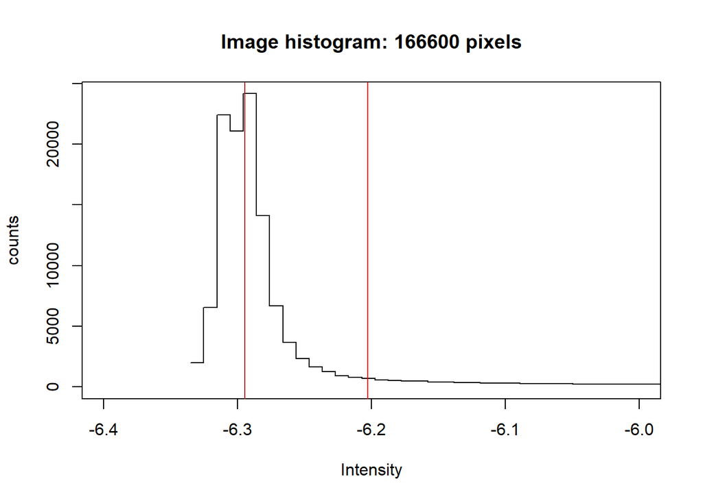

```r
hist(log(cellsSmooth_gaus[,,3]), xlim =  -c(6.4, 6.0), breaks = 300)
abline(v = cellBg[c("loc", "thr"), 3], col = c("brown", "red"))
```

A recap of variables (how they were computed)

```r
#nucThresh = (cellsSmooth_gaus_norm[,,1] - filter2(cellsSmooth_gaus_norm[,,1], disc) > offset)
#nucOpened = EBImage::opening(nucThresh, kern = makeBrush(5, shape = "disc"))
#nucSeed = bwlabel(nucOpened)
#nuclei = propagate(cellsSmooth[,,1], nucSeed, mask = nucOpened)
```

```r
cytoplasmMask = (cellsSmooth_gaus[,,2] > exp(cellBg["thr", 2])) |
       nuclei | (cellsSmooth_gaus[,,3] > exp(cellBg["thr", 3]))
cytoplasmMask
```

[output not shown]

```r
cellbodies = propagate(x = cellsSmooth_gaus[,,3], seeds = nuclei,
                       lambda = 1.0e-2, mask = cytoplasmMask)
cellbodies
```

```
## Image
##   colorMode    : Grayscale
##   storage.mode : integer
##   dim          : 340 490
##   frames.total : 1
##   frames.render: 1
##
## imageData(object)[1:5,1:6]
##      [,1] [,2] [,3] [,4] [,5] [,6]
## [1,]    0    0    0    0    0    0
## [2,]    0    0    0    0    0    0
## [3,]    0    0    0    0    0    0
## [4,]    0    0    0    0    0    0
## [5,]    0    0    0    0    0    0
```

Visualize segmentation of cell bodies

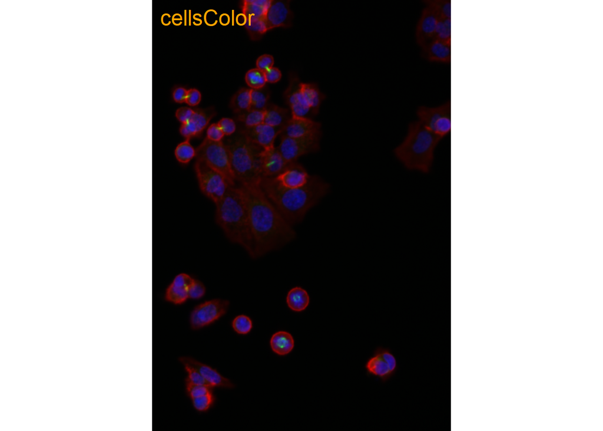

```r
cellsColor = EBImage::rgbImage(red   = cells[,,3],
                               green = cells[,,2],
                               blue  = cells[,,1])
nucSegOnNuc  = paintObjects(nuclei, tgt = EBImage::toRGB(cells[,,1]), col = "#ffff00")
nucSegOnAll  = paintObjects(nuclei,     tgt = cellsColor,    col = "#ffff00")
cellSegOnAll = paintObjects(cellbodies, tgt = nucSegOnAll,   col = "#ff0080")

EBImage::display(normalize(cellsColor, ft=c(0,1)), method = 'raster')
text(x = 10, y = 20, label = "cellsColor", adj = 0, col = "orange", cex = 1.5)
```

[figure not shown]

```r
EBImage::display(normalize(nucSegOnNuc, ft=c(0,1)), method = 'raster')
text(x = 10, y = 20, label = "nucSegOnNuc", adj = 0, col = "orange", cex = 1.5)
```

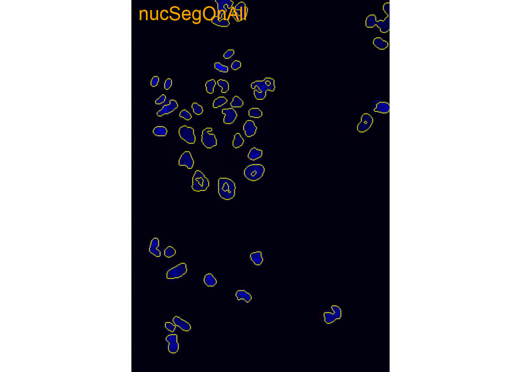

```r
EBImage::display(normalize(nucSegOnAll, ft=c(0,1)), method = 'raster')
text(x = 10, y = 20, label = "nucSegOnAll", adj = 0, col = "orange", cex = 1.5)
```

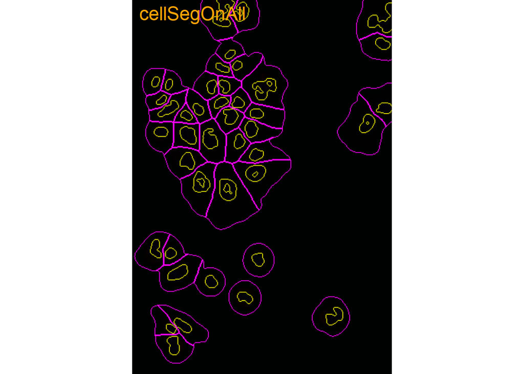

```r
EBImage::display(normalize(cellSegOnAll, ft=c(0,1)), method = 'raster')
text(x = 10, y = 20, label = "cellSegOnAll", adj = 0, col = "orange", cex = 1.5)
```

### 4. Feature extraction

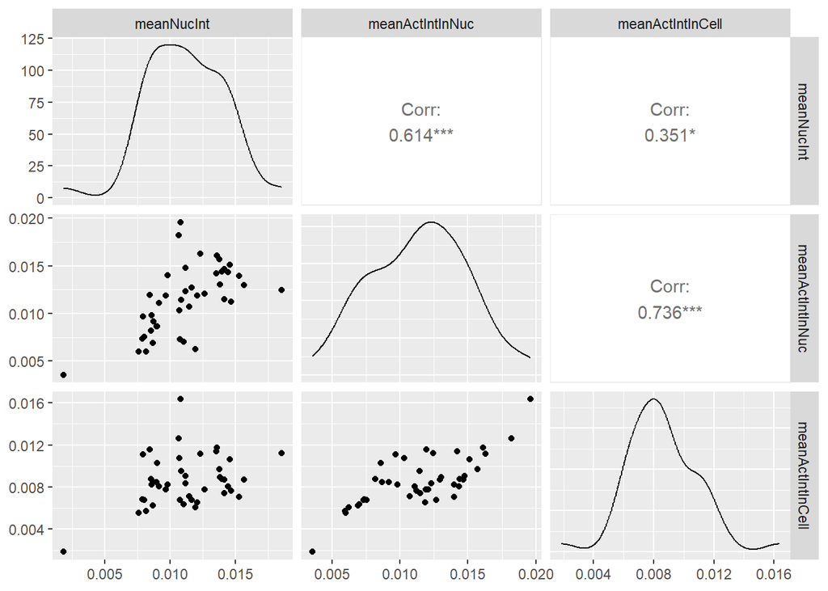

```r
meanNucInt       = tapply(cells[,,1], nuclei, mean)
meanActIntInNuc  = tapply(cells[,,3], nuclei, mean)
meanActIntInCell = tapply(cells[,,3], cellbodies, mean)
GGally::ggpairs(tibble(meanNucInt, meanActIntInNuc, meanActIntInCell))
```

EBImage::computeFeatures- Computes morphological and texture features from image objects. computeFeatures.basic -b.mean: mean intensity -b.sd: standard deviation intensity -b.mad: mad intensity -b.q*: quantile intensity

computeFeatures.shape -s.area: area size (in pixels) -s.perimeter: perimeter (in pixels) -s.radius.mean: mean radius (in pixels) -s.radius.sd: standard deviation of the mean radius (in pixels) -s.radius.max: max radius (in pixels) -s.radius.min: min radius (in pixels)

```r
F1 = computeFeatures(nuclei,     cells[,,1], xname = "nuc",  refnames = "nuc")
F2 = computeFeatures(cellbodies, cells[,,2], xname = "cell", refnames = "tub")
F3 = computeFeatures(cellbodies, cells[,,3], xname = "cell", refnames = "act")
F1[1:3, 1:5]
```

```
##   nuc.0.m.cx nuc.0.m.cy nuc.0.m.majoraxis nuc.0.m.eccentricity nuc.0.m.theta
## 1   119.5752   17.65143          45.80516            0.8568349    -1.3170487
## 2   143.7618   15.87059          27.21574            0.7158443    -1.2322795
## 3   327.8789   26.99171          42.57228            0.6136401    -0.7356435
```